# SF_01_FRGN_REG_NUM_EMPL_CONTIN

Total from continuation sheets to Part 1 number of employees, agents, and independent contractors · Number report

## Overview

**Description**

Total number of employees from continuation sheets working on region activities outside the US (Part I)

**Table**

`SF-P01-T00-FRGN-ACTS` (one)

**Location code**

`SCHED-F-PART-01-LINE-03B-COL-C`

**Family**

`SCHED-F-PART-01-LINE-03B-COL-C`

**Data type**

numeric (xsd: IntegerNNType)

**Scope**

PC

**Status**

unreviewed

3

xpaths mapped (3 observed)

92,314

filings with a value

2010–2024

tax years observed

0

open flags (0 errors)

## Flags

No open flags.

## Xpaths

All mapped xpaths (under /Return/ReturnData or /Return/ReturnHeader), oldest first. Charts label each series by its xpath.

| Xpath | Form | First year | Last year | Versions | Filings | Repeats in |
| --- | --- | --- | --- | --- | --- | --- |
| IRS990ScheduleF/ContNumberOfEmployees | Sched F | 2010 | 2012 | 11 | 10,428 | 0.0% |
| IRS990ScheduleF/ContinutationTotalEmployeeCnt | Sched F | 2013 | 2016 | 9 | 21,598 | 0.0% |
| IRS990ScheduleF/ContinuationTotalEmployeeCnt | Sched F | 2017 | 2024 | 25 | 60,288 | 0.0% |

## Coverage

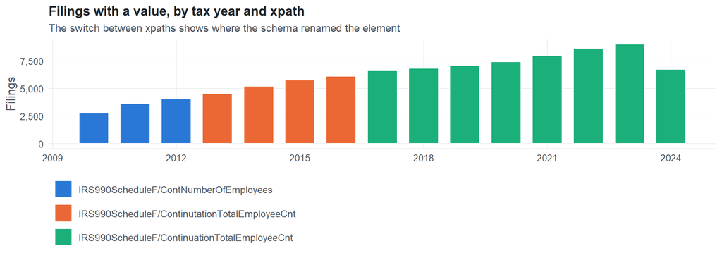

**Table view**

Table view: filings by tax year and series

| Tax year | IRS990ScheduleF/ContNumberOfEmployees | IRS990ScheduleF/ContinutationTotalEmployeeCnt | IRS990ScheduleF/ContinuationTotalEmployeeCnt |
| --- | --- | --- | --- |
| 2010 | 2,761 | 0 | 0 |
| 2011 | 3,622 | 0 | 0 |
| 2012 | 4,045 | 0 | 0 |
| 2013 | 0 | 4,508 | 0 |
| 2014 | 0 | 5,208 | 0 |
| 2015 | 0 | 5,763 | 0 |
| 2016 | 0 | 6,119 | 0 |
| 2017 | 0 | 0 | 6,602 |
| 2018 | 0 | 0 | 6,823 |
| 2019 | 0 | 0 | 7,066 |
| 2020 | 0 | 0 | 7,415 |
| 2021 | 0 | 0 | 7,996 |
| 2022 | 0 | 0 | 8,641 |
| 2023 | 0 | 0 | 9,010 |
| 2024 | 0 | 0 | 6,735 |

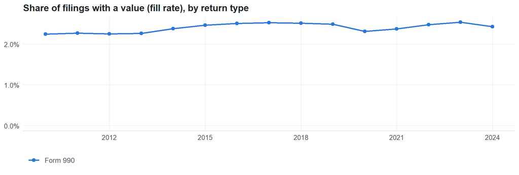

**Table view**

Table view: fill rate

| Tax year | Return type | Filings | All filings | Fill rate |
| --- | --- | --- | --- | --- |
| 2010 | Form 990 | 2,761 | 123,025 | 2.24% |
| 2011 | Form 990 | 3,622 | 159,504 | 2.27% |
| 2012 | Form 990 | 4,045 | 179,688 | 2.25% |
| 2013 | Form 990 | 4,508 | 198,855 | 2.27% |
| 2014 | Form 990 | 5,208 | 218,619 | 2.38% |
| 2015 | Form 990 | 5,763 | 233,519 | 2.47% |
| 2016 | Form 990 | 6,119 | 243,903 | 2.51% |
| 2017 | Form 990 | 6,602 | 261,612 | 2.52% |
| 2018 | Form 990 | 6,823 | 271,442 | 2.51% |
| 2019 | Form 990 | 7,066 | 283,694 | 2.49% |
| 2020 | Form 990 | 7,415 | 320,342 | 2.31% |
| 2021 | Form 990 | 7,996 | 336,480 | 2.38% |
| 2022 | Form 990 | 8,641 | 349,055 | 2.48% |
| 2023 | Form 990 | 9,010 | 354,768 | 2.54% |
| 2024 | Form 990 | 6,735 | 277,298 | 2.43% |

## Values

[output not shown]

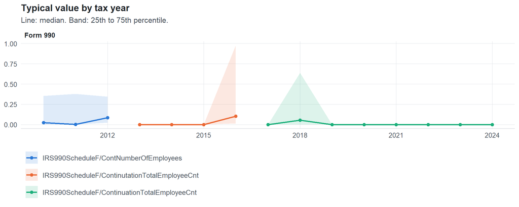

**Table view**

Table view: quartiles by tax year

| Series | Return | Tax year | Filings | P25 | Median | P75 |
| --- | --- | --- | --- | --- | --- | --- |
| IRS990ScheduleF/ContNumberOfEmployees | 990 | 2010 | 2,761 | 0 | 0.03 | 0.35 |
| IRS990ScheduleF/ContNumberOfEmployees | 990 | 2011 | 3,622 | 0 | 0.00 | 0.38 |
| IRS990ScheduleF/ContNumberOfEmployees | 990 | 2012 | 4,045 | 0.02 | 0.08 | 0.35 |
| IRS990ScheduleF/ContinutationTotalEmployeeCnt | 990 | 2013 | 4,508 | 0 | 0 | 0.00 |
| IRS990ScheduleF/ContinutationTotalEmployeeCnt | 990 | 2014 | 5,208 | 0 | 0 | 0 |
| IRS990ScheduleF/ContinutationTotalEmployeeCnt | 990 | 2015 | 5,763 | 0 | 0 | 0 |
| IRS990ScheduleF/ContinutationTotalEmployeeCnt | 990 | 2016 | 6,119 | 0.01 | 0.10 | 0.98 |
| IRS990ScheduleF/ContinuationTotalEmployeeCnt | 990 | 2017 | 6,602 | 0 | 0 | 0 |
| IRS990ScheduleF/ContinuationTotalEmployeeCnt | 990 | 2018 | 6,823 | 0.00 | 0.05 | 0.64 |
| IRS990ScheduleF/ContinuationTotalEmployeeCnt | 990 | 2019 | 7,066 | 0 | 0 | 0 |
| IRS990ScheduleF/ContinuationTotalEmployeeCnt | 990 | 2020 | 7,415 | 0 | 0 | 0 |
| IRS990ScheduleF/ContinuationTotalEmployeeCnt | 990 | 2021 | 7,996 | 0 | 0 | 0 |
| IRS990ScheduleF/ContinuationTotalEmployeeCnt | 990 | 2022 | 8,641 | 0 | 0 | 0 |
| IRS990ScheduleF/ContinuationTotalEmployeeCnt | 990 | 2023 | 9,010 | 0 | 0 | 0 |
| IRS990ScheduleF/ContinuationTotalEmployeeCnt | 990 | 2024 | 6,735 | 0 | 0 | 0 |

Summary by xpath and return type (all years)

| Series | Return | Filings | % numeric | % zero | % negative | Median (typical year) | P99 (typical year) |
| --- | --- | --- | --- | --- | --- | --- | --- |
| IRS990ScheduleF/ContNumberOfEmployees | 990 | 10,428 | 100 | 97.01 | 0 | 0 | 77 |
| IRS990ScheduleF/ContinutationTotalEmployeeCnt | 990 | 21,598 | 100 | 97.35 | 0 | 0 | 128 |
| IRS990ScheduleF/ContinuationTotalEmployeeCnt | 990 | 60,288 | 100 | 97.22 | 0 | 0 | 29 |

Scale of each xpath

| Series | P99 (typical year) | Implied scale |
| --- | --- | --- |
| IRS990ScheduleF/ContNumberOfEmployees | 77 | percent or small count |
| IRS990ScheduleF/ContinuationTotalEmployeeCnt | 29 | percent or small count |
| IRS990ScheduleF/ContinutationTotalEmployeeCnt | 128 | large count or amount |

## Examples

| Tax year | Return | Xpath | Organization | Value | Source |
| --- | --- | --- | --- | --- | --- |
| 2024 | 990 | IRS990ScheduleF/ContinuationTotalEmployeeCnt | THE CLEVELAND CLINIC FOUNDATION | 0 | [XML](https://gt990datalake-rawdata.s3.amazonaws.com/EfileData/XmlFiles/202513189349302136_public.xml) |
| 2023 | 990 | IRS990ScheduleF/ContinuationTotalEmployeeCnt | YOUNG PRESIDENTS ORGANIZATION | 0 | [XML](https://gt990datalake-rawdata.s3.amazonaws.com/EfileData/XmlFiles/202443199349317374_public.xml) |
| 2022 | 990 | IRS990ScheduleF/ContinuationTotalEmployeeCnt | INTERNATIONAL FEDERATION OF CLINICAL | 0 | [XML](https://gt990datalake-rawdata.s3.amazonaws.com/EfileData/XmlFiles/202341789349301384_public.xml) |
| 2021 | 990 | IRS990ScheduleF/ContinuationTotalEmployeeCnt | BAR ILAN UNIVERSITY IN ISRAEL INC | 0 | [XML](https://gt990datalake-rawdata.s3.amazonaws.com/EfileData/XmlFiles/202322269349302912_public.xml) |
| 2020 | 990 | IRS990ScheduleF/ContinuationTotalEmployeeCnt | NEW DAY FOUNDATION INC | 0 | [XML](https://gt990datalake-rawdata.s3.amazonaws.com/EfileData/XmlFiles/202121249349300937_public.xml) |
| 2019 | 990 | IRS990ScheduleF/ContinuationTotalEmployeeCnt | INTERFAITH PEACE BUILDERS | 0 | [XML](https://gt990datalake-rawdata.s3.amazonaws.com/EfileData/XmlFiles/202121309349302482_public.xml) |
| 2018 | 990 | IRS990ScheduleF/ContinuationTotalEmployeeCnt | BRANDEIS HILLEL DAY SCHOOL - MARIN | 0 | [XML](https://gt990datalake-rawdata.s3.amazonaws.com/EfileData/XmlFiles/202041969349303794_public.xml) |
| 2017 | 990 | IRS990ScheduleF/ContinuationTotalEmployeeCnt | AMERICAS SOCIETY INC | 0 | [XML](https://gt990datalake-rawdata.s3.amazonaws.com/EfileData/XmlFiles/201823199349310107_public.xml) |
| 2016 | 990 | IRS990ScheduleF/ContinutationTotalEmployeeCnt | Friends of East Africa Foundation | 0 | [XML](https://gt990datalake-rawdata.s3.amazonaws.com/EfileData/XmlFiles/201711869349300316_public.xml) |
| 2015 | 990 | IRS990ScheduleF/ContinutationTotalEmployeeCnt | AMERICAN SOCIETY OF AGRONOMY | 0 | [XML](https://gt990datalake-rawdata.s3.amazonaws.com/EfileData/XmlFiles/201611589349300921_public.xml) |
| 2014 | 990 | IRS990ScheduleF/ContinutationTotalEmployeeCnt | COLLEGE OF OUR LADY OF THE ELMS | 0 | [XML](https://gt990datalake-rawdata.s3.amazonaws.com/EfileData/XmlFiles/201630479349301833_public.xml) |
| 2013 | 990 | IRS990ScheduleF/ContinutationTotalEmployeeCnt | THE WFG FOUNDATION INC | 0 | [XML](https://gt990datalake-rawdata.s3.amazonaws.com/EfileData/XmlFiles/201413219349306711_public.xml) |

## Reviewer checklist

- The definition matches the form line and instructions for every xpath’s schema years.
- Every xpath pooled here measures the same thing on the 990 and 990-EZ (close enough for analysis).
- The coverage chart has no unexplained gaps or jumps between tax years.
- Each open flag is fixed, or accepted with a note in validation_log.csv.
- Counts are whole numbers and plausible (e.g. employees, volunteers, voting members).
- Ratios and percentages use one scale (0-1 or 0-100) across all xpaths and years.
- Units match the form line (hours per week, number of states, percent of support).

Record the review as a row in `inst/extdata/src/validation_log.csv` (variable_name, reviewer, date, status, note). Evidence built 2026-09-23 17:09:04 MST from the ef2 DuckDB builds (tax years 2009–2024).